# R Notebook

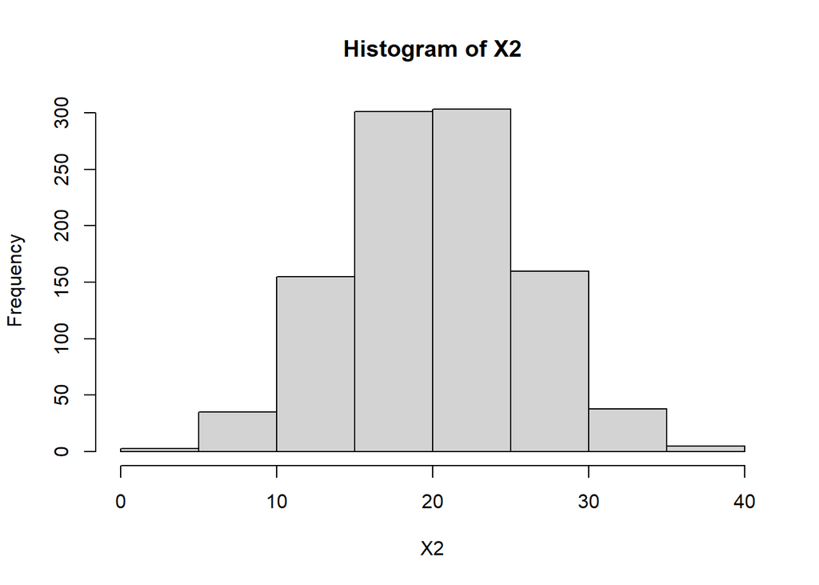

```r
hist(X2)
```

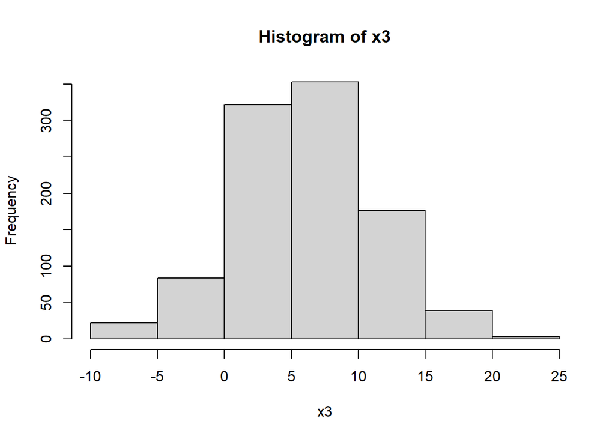

```r
x3=rnorm(1000,mean = 5.782748,sd=5)
hist(x3)
```

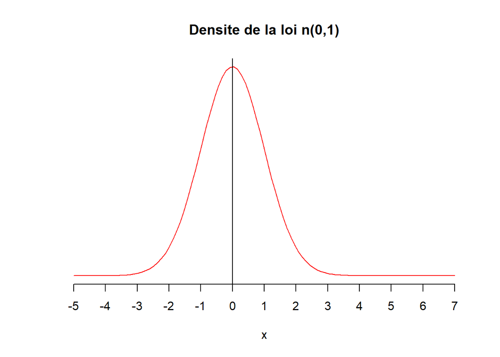

```r
curve(dnorm(x,mean = 0,sd=1),from = -5,to =7 ,col="red",main="Densite de la loi n(0,1)",axes=F,ylab="")
axis(1,xaxp=c(-5,7,12))
axis(2,pos=0,c(-1,1))
```

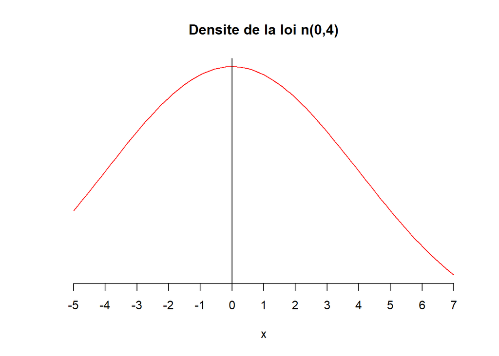

```r
curve(dnorm(x,mean = 0,sd=4),from = -5,to =7 ,col="red",main="Densite de la loi n(0,4)",axes=F,ylab="")
axis(1,xaxp=c(-5,7,12))
axis(2,pos=0,c(-1,1))
```

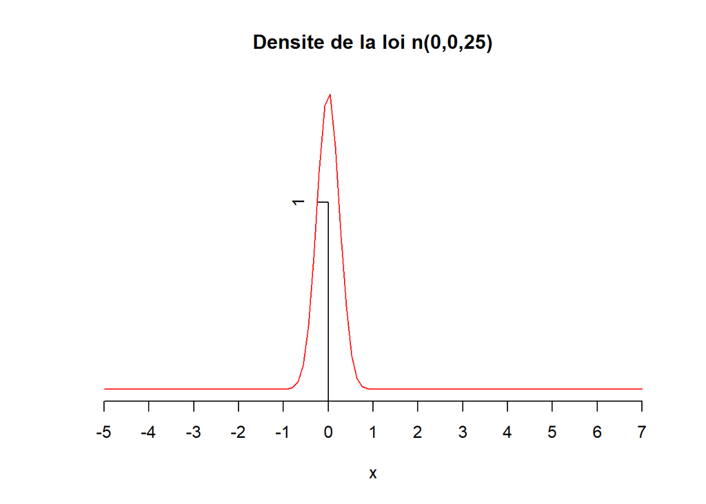

```r
curve(dnorm(x,mean = 0,sd=1/4),from = -5,to =7 ,col="red",main="Densite de la loi n(0,0,25)",axes=F,ylab="")
axis(1,xaxp=c(-5,7,12))
axis(2,pos=0,c(-1,1))
```

## **Exercice 3 Loi exponentielle**

Soit X4 E (0.4)

1. **Effectuez une simulation de 1000 tirages de X4 et dessinez l’istogramme obtenu**

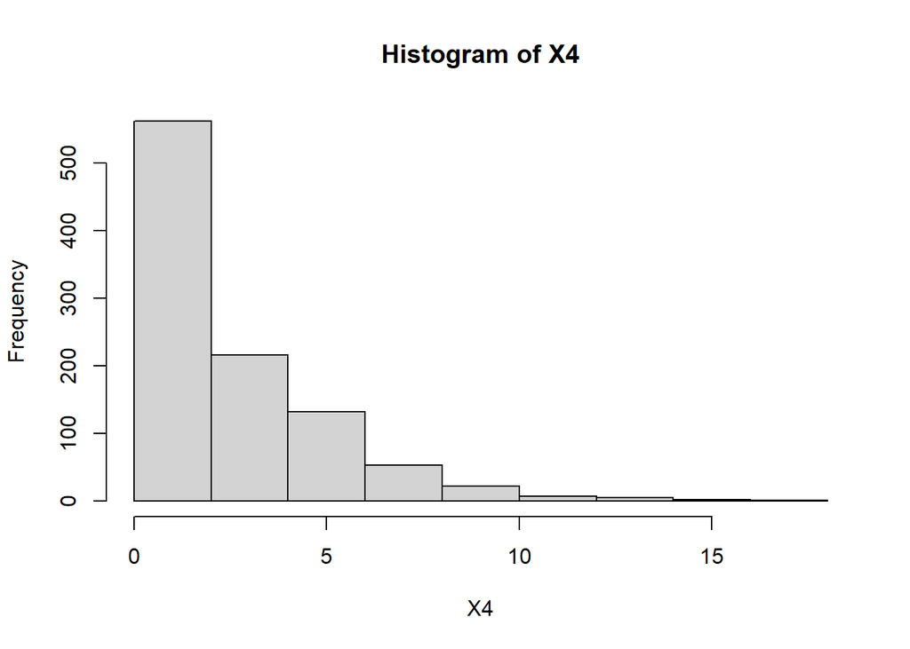

```r
X4<-rexp(1000,0.4)
hist(X4)
```

2. **Comparez la moyenne et l’écart-type obtenus avec ceux donnés par la théorie**

```r
mean(X4)
```

```
## [1] 2.512187
```

```r
sd(X4)
```

```
## [1] 2.439604
```

**`la moyenne non theorrique`**

```r
th=rexp(1000,rate=0.4)
mean(th)
```

```
## [1] 2.325431
```

```r
th=rexp(1000,rate=0.4)
sd(th)
```

```
## [1] 2.336812
```

3. **Dessinez la courbe de la densité de probabilité de X4**

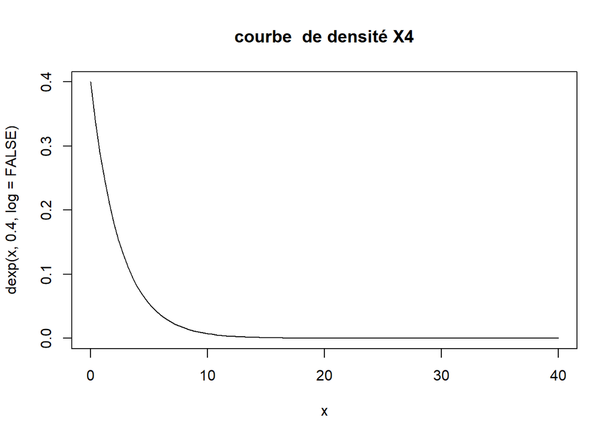

```r
curve(dexp(x,0.4,log=FALSE),from = 0,to = 40,main = "courbe  de densité X4")
```

4. **Quelle est la valeur de la médiane de X4 ?**

```r
median(X4)
```

```
## [1] 1.671278
```

## Exercice 4 Loi Gamma

[figure not shown]

```r
alpha=1
beta=10
x=1:10
curve(dgamma(x,shape=alpha,scale=beta), from = 0, to = 10, col = "green", lwd = 3, xlab = "valeurs", ylab = "Frequence",main = "la fonction x 7→ Γ(x) ")
```

2. **Vérifiez que pour n entier on a : Γ(n) = (n − 1)!**

```r
x <- gamma(3)
x
```

```
## [1] 2
```

```r
x1=2*1
x1
```

```
## [1] 2
```

3. **Dessinez sur un même graphique les densités de probabilité correspondant à des variables aléatoires suivant des lois Gamma : γ2, γ3, γ5**

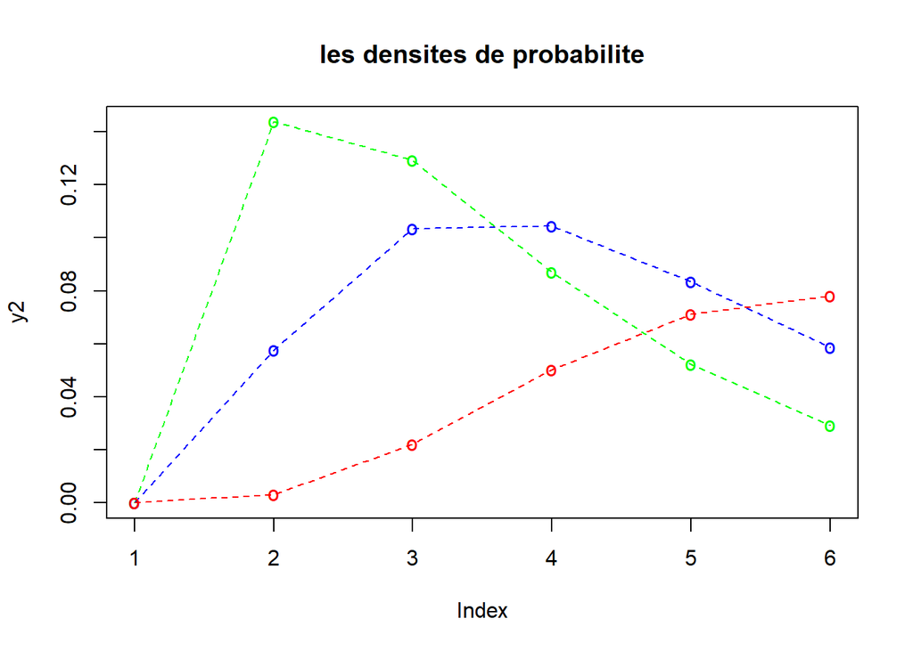

```r
x<-c(0,2,4,6,8,10)
y2<-dgamma(x,shape=2,rate=0.4)
y3<-dgamma(x,shape=3,rate=0.4)
y5<-dgamma(x,shape=5,rate=0.4)

plot(y2,type="o", col="green", pch="o", lty=2, main="les densites de probabilite")
lines(y3,type="o",  col="blue", pch="o", lty=2)
lines(y5, type="o",col="red", pch="o", lty=2)
```

## Exercice 5

Loi du χ 2 Soit X5 = χ2(10) une variable aléatoire qui suit une loi du χ 2 à 10 degrés de liberté (ddl = 10).

1. **Dessinez la courbe de la densité de probabilité de X5 sur [0; 20]**

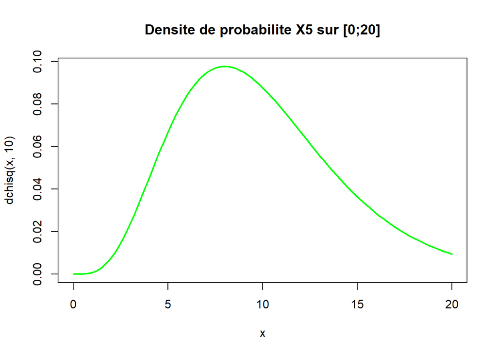

```r
curve(dchisq(x, 10), from = 0, to = 20, col = "green", lwd = 2,main = "Densite de probabilite X5 sur [0;20]")
```

2. **Faites une simulation de 1000 tirages de X5 et dessinez l’histogramme correspondant. Vérifiez que la moyenne et l’écart-type obtenus sont proches des valeurs attendues.**

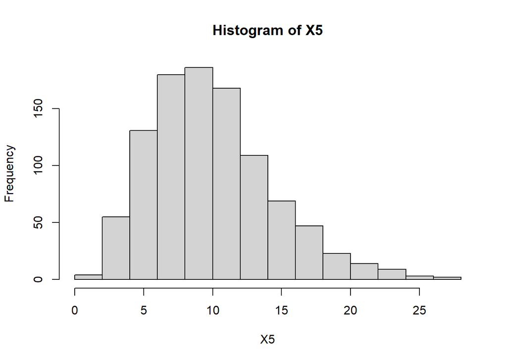

```r
X5 <- rchisq(1000, 10)
hist(X5)
```

**Le Moyenne**

```r
Moyenne <- mean(X5)
Moyenne
```

```
## [1] 9.908786
```

**L’écart-type**

```r
Ecarttype <- sd(X5)
Ecarttype
```

```
## [1] 4.367599
```

## Exercice 6 Loi de Student

Soit X6 ❀ St(10) une variable aléatoire qui suit une loi de Student à 10 degrés de liberté (ddl = 10).

**1. Dessinez la courbe de la densité de probabilité de X6**

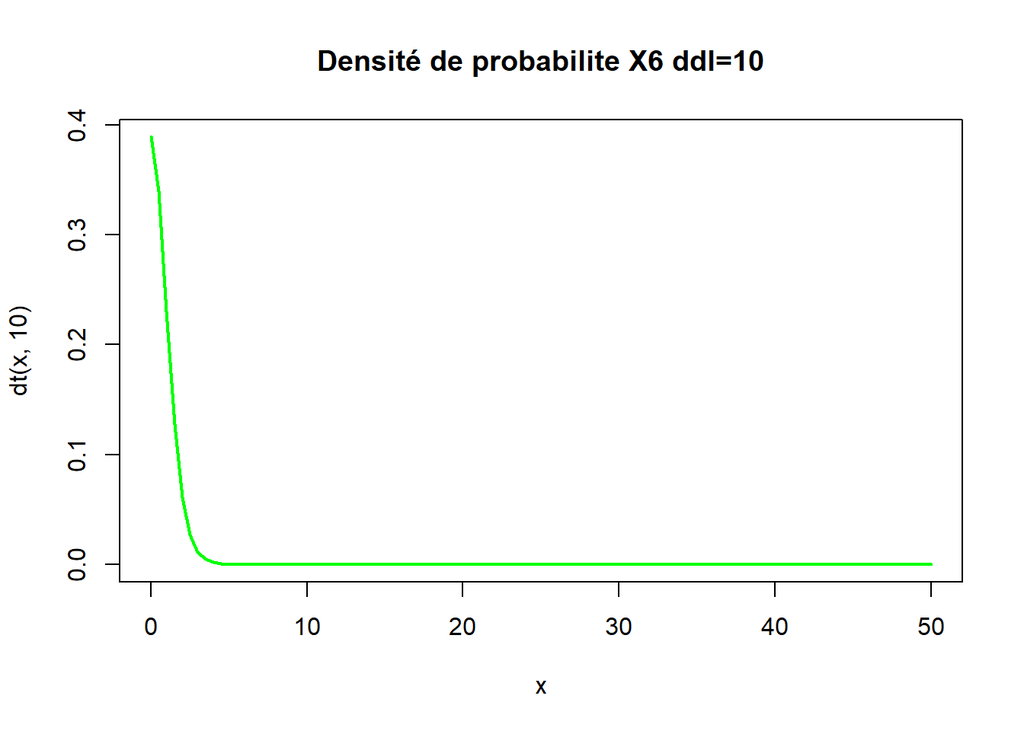

```r
curve(dt(x, 10), from = 0, to = 50, col = "green", lwd = 2,main = "Densité de probabilite X6 ddl=10")
```

2. **Faites une simulation de 1000 tirages de X6 et dessinez l’histogramme correspondant. Vérifiez que la moyenne et l’écart-type obtenus sont proches des valeurs attendues.**

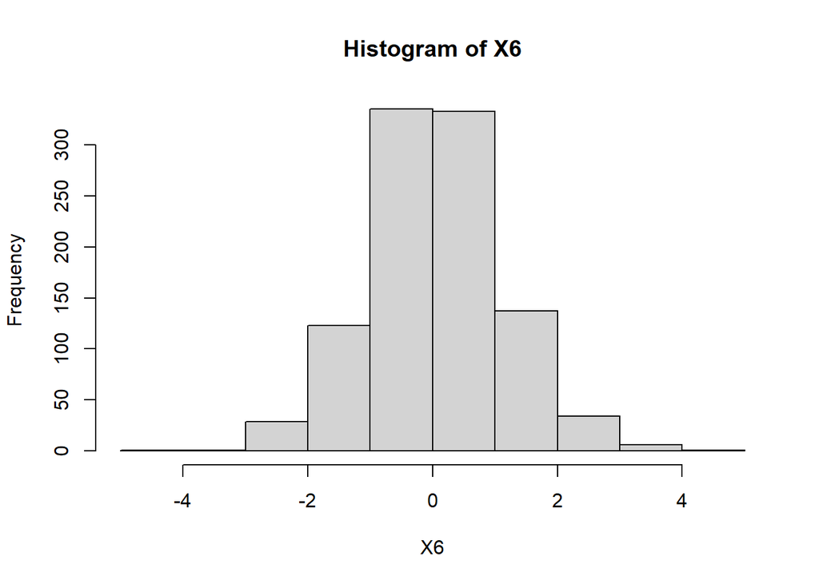

```r
X6 <- rt(1000, 10)
hist(X6)
```

**La moyenne**

```r
Moyenne <- mean(X6)
Moyenne
```

```
## [1] 0.04093532
```

**l’écart-type**

```r
Ecarttype <- sd(X6)
Ecarttype
```

```
## [1] 1.086782
```